# Debate_Important_Topics

# Referred to the Important Topics in the debate

In this short write-up, I’ll look at the 4 important topics Jobs, Terrorism, immigration and health and how the the presidential candidates have used them during the first debate. * How often have the candidates used words similar to the 4 most important topics

The figure below shows the frequency of each important word pronoun as a percentage of each candidates’ total words used.

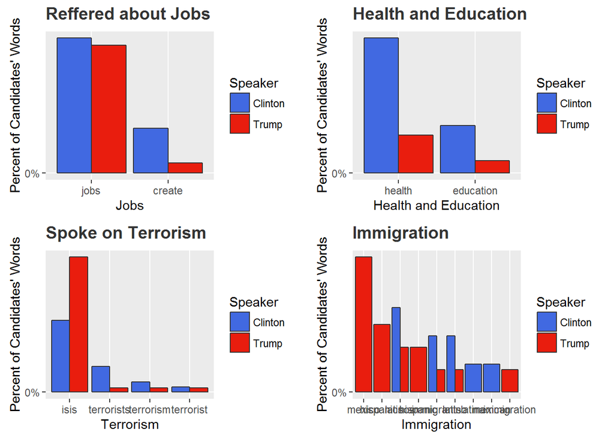

## Unique words used

The figure below shows us the total number of unique words used by each line in the transcript. It looks like Hillary may have a slight edge by the end of the debate, but it’s not a wopping difference to me. Their unique word usage is pretty overlapped between lines 125 and 175.

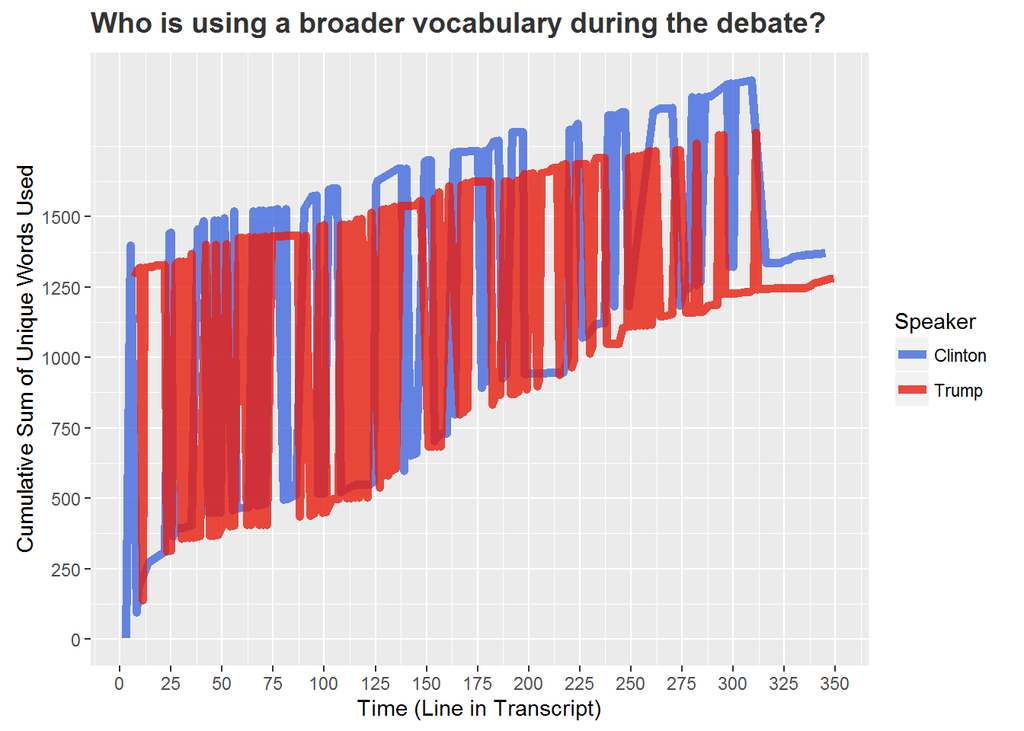